# Kaggle 타이타닉 생존자 예측

# 타이타닉 생존자 예측 문제 개요

- 이런 유형의 문제를 .. 분류와 계층 확률 추정이라고 함
  - 각 개인이 어느 계층에 속할지를 예측하는 것
  - 일반적으로 계측은 상호 배타적임
  - ex) “메가텔 고객 중 마케팅 제안을 받아들일 가능성이 잇는 고객은?” 과 같은 질문에 대해 수용하는 계층과 거부하는 계층으로 나누는 경우

# 데이터 로딩에서 EDA 까지

## 데이터 불러오기

```r
options(width=150)

# Titanic.path <- "/home/machi/r-test/11장_타이타닉예제/"
# Titanic.path <- "C:\\test\\r_test\\11장_타이타닉예제\\"
#Titanic.path <- "C:\\\\Users/user/Documents/eda/"
Titanic.path <- "https://raw.github.com/wehrley/Kaggle_Titanic/master/"

train.data.file <- "train.csv"
test.data.file <- "test.csv"  ## Survived 칼럼 값이 없음
missing.types <- c("NA", "")

## 타입을 지정함
train.column.types <- c('integer',   # PassengerId
                        'factor',    # Survived
                        'factor',    # Pclass, 1,2,3등석
                        'character', # Name
                        'factor',    # Sex
                        'numeric',   # Age
                        'integer',   # SibSp, 함께 탑승한 형제 또는 배우자
                        'integer',   # Parch, 함께 탑승한 부모 또는 자녀의 수
                        'character', # Ticket, 티켓 번호
                        'numeric',   # Fare, 티켓 요금
                        'character', # Cabin, 선실번호
                        'factor'     # Embarked , 탑승한 곳
)

##  # no Survived column in test.csv
test.column.types <- train.column.types[-2]

readData <- function(path.name, file.name, column.types, missing.types) {
#   read.csv( url( paste(path.name, file.name, sep="") ),
  read.csv( paste(path.name, file.name, sep=""),
            colClasses=column.types,
            na.strings=missing.types , stringsAsFactors = F)
}
```

## 테스트 데이터 분리

```r
train.raw <- readData(Titanic.path, train.data.file,
                      train.column.types, missing.types)
df.train <- train.raw
str(df.train)
```

```
## 'data.frame':    891 obs. of  12 variables:
##  $ PassengerId: int  1 2 3 4 5 6 7 8 9 10 ...
##  $ Survived   : Factor w/ 2 levels "0","1": 1 2 2 2 1 1 1 1 2 2 ...
##  $ Pclass     : Factor w/ 3 levels "1","2","3": 3 1 3 1 3 3 1 3 3 2 ...
##  $ Name       : chr  "Braund, Mr. Owen Harris" "Cumings, Mrs. John Bradley (Florence Briggs Thayer)" "Heikkinen, Miss. Laina" "Futrelle, Mrs. Jacques Heath (Lily May Peel)" ...
##  $ Sex        : Factor w/ 2 levels "female","male": 2 1 1 1 2 2 2 2 1 1 ...
##  $ Age        : num  22 38 26 35 35 NA 54 2 27 14 ...
##  $ SibSp      : int  1 1 0 1 0 0 0 3 0 1 ...
##  $ Parch      : int  0 0 0 0 0 0 0 1 2 0 ...
##  $ Ticket     : chr  "A/5 21171" "PC 17599" "STON/O2. 3101282" "113803" ...
##  $ Fare       : num  7.25 71.28 7.92 53.1 8.05 ...
##  $ Cabin      : chr  NA "C85" NA "C123" ...
##  $ Embarked   : Factor w/ 3 levels "C","Q","S": 3 1 3 3 3 2 3 3 3 1 ...
```

```r
df.train$Survived <- factor(df.train$Survived, levels=c(0,1),labels=c("dead","Survived"))
# names(df.train)
levels(df.train$Embarked)
```

```
## [1] "C" "Q" "S"
```

```r
table(df.train$Embarked)
```

```
##
##   C   Q   S
## 168  77 644
```

```r
# table(df.train.train$Cabin)

test.raw <- readData(Titanic.path, test.data.file, test.column.types, missing.types)
df.infer <- test.raw
```

## Data Munging

```r
# install.packages("Hmisc")
suppressPackageStartupMessages({
  library(Hmisc)
})
## method="reverse" 는 종속변수 survived 에 따라 독립 변수들을 분할하여 보여줌

names(df.train)
```

```
##  [1] "PassengerId" "Survived"    "Pclass"      "Name"        "Sex"         "Age"         "SibSp"       "Parch"       "Ticket"      "Fare"
## [11] "Cabin"       "Embarked"
```

```r
summary(Survived ~ Pclass + Sex + Age + SibSp + Parch + Fare + Embarked, data = df.train,
        method="reverse")
```

```
##
##
## Descriptive Statistics by Survived
##
## +------------+---+-----------------------+-----------------------+
## |            |N  |dead                   |Survived               |
## |            |   |(N=549)                |(N=342)                |
## +------------+---+-----------------------+-----------------------+
## |Pclass : 1  |891|       15% ( 80)       |       40% (136)       |
## +------------+---+-----------------------+-----------------------+
## |    2       |   |       18% ( 97)       |       25% ( 87)       |
## +------------+---+-----------------------+-----------------------+
## |    3       |   |       68% (372)       |       35% (119)       |
## +------------+---+-----------------------+-----------------------+
## |Sex : male  |891|       85% (468)       |       32% (109)       |
## +------------+---+-----------------------+-----------------------+
## |Age         |714|        21/28/39       |        19/28/36       |
## +------------+---+-----------------------+-----------------------+
## |SibSp : 0   |891|       72% (398)       |       61% (210)       |
## +------------+---+-----------------------+-----------------------+
## |    1       |   |       18% ( 97)       |       33% (112)       |
## +------------+---+-----------------------+-----------------------+
## |    2       |   |        3% ( 15)       |        4% ( 13)       |
## +------------+---+-----------------------+-----------------------+
## |    3       |   |        2% ( 12)       |        1% (  4)       |
## +------------+---+-----------------------+-----------------------+
## |    4       |   |        3% ( 15)       |        1% (  3)       |
## +------------+---+-----------------------+-----------------------+
## |    5       |   |        1% (  5)       |        0% (  0)       |
## +------------+---+-----------------------+-----------------------+
## |    8       |   |        1% (  7)       |        0% (  0)       |
## +------------+---+-----------------------+-----------------------+
## |Parch : 0   |891|       81% (445)       |       68% (233)       |
## +------------+---+-----------------------+-----------------------+
## |    1       |   |       10% ( 53)       |       19% ( 65)       |
## +------------+---+-----------------------+-----------------------+
## |    2       |   |        7% ( 40)       |       12% ( 40)       |
## +------------+---+-----------------------+-----------------------+
## |    3       |   |        0% (  2)       |        1% (  3)       |
## +------------+---+-----------------------+-----------------------+
## |    4       |   |        1% (  4)       |        0% (  0)       |
## +------------+---+-----------------------+-----------------------+
## |    5       |   |        1% (  4)       |        0% (  1)       |
## +------------+---+-----------------------+-----------------------+
## |    6       |   |        0% (  1)       |        0% (  0)       |
## +------------+---+-----------------------+-----------------------+
## |Fare        |891| 7.8542/10.5000/26.0000|12.4750/26.0000/57.0000|
## +------------+---+-----------------------+-----------------------+
## |Embarked : C|889|       14% ( 75)       |       27% ( 93)       |
## +------------+---+-----------------------+-----------------------+
## |    Q       |   |        9% ( 47)       |        9% ( 30)       |
## +------------+---+-----------------------+-----------------------+
## |    S       |   |       78% (427)       |       64% (217)       |
## +------------+---+-----------------------+-----------------------+
```

```r
## 이를 그래프로 확인을
# install.packages("Amelia")
require(Amelia)
```

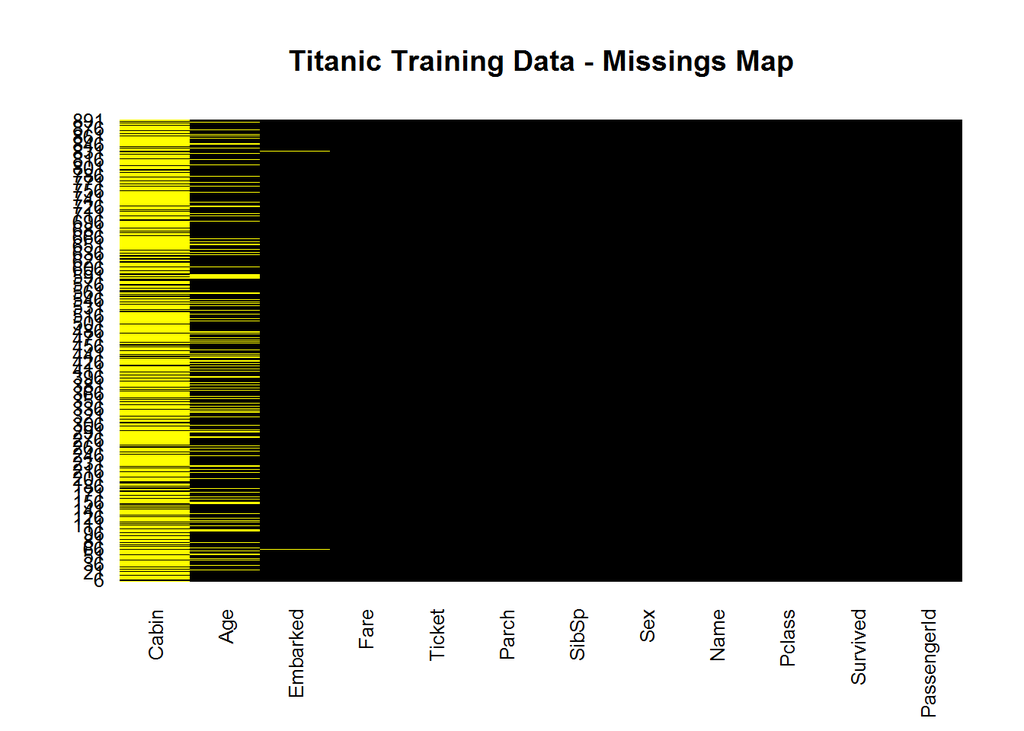

```r
missmap(df.train, main="Titanic Training Data - Missings Map",
        col=c("yellow", "black"), legend=FALSE)
```

```r
## 실제 Embarked 필드에서 null 값이 있는 행에 대해서 확인을
knitr::kable(df.train[!complete.cases(df.train$Embarked),])
```

|  | PassengerId | Survived | Pclass | Name | Sex | Age | SibSp | Parch | Ticket | Fare | Cabin | Embarked |
| --- | --- | --- | --- | --- | --- | --- | --- | --- | --- | --- | --- | --- |
| 62 | 62 | Survived | 1 | Icard, Miss. Amelie | female | 38 | 0 | 0 | 113572 | 80 | B28 | NA |
| 830 | 830 | Survived | 1 | Stone, Mrs. George Nelson (Martha Evelyn) | female | 62 | 0 | 0 | 113572 | 80 | B28 | NA |

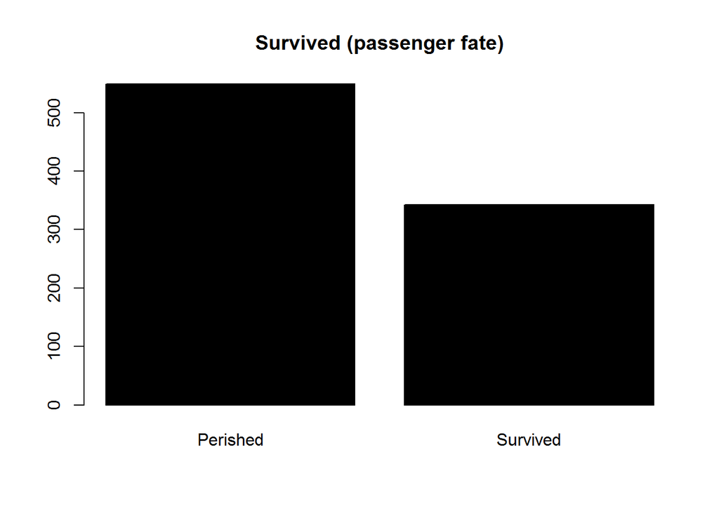

```r
barplot(table(df.train$Survived),
        names.arg = c("Perished", "Survived"),
        main="Survived (passenger fate)", col="black")
```

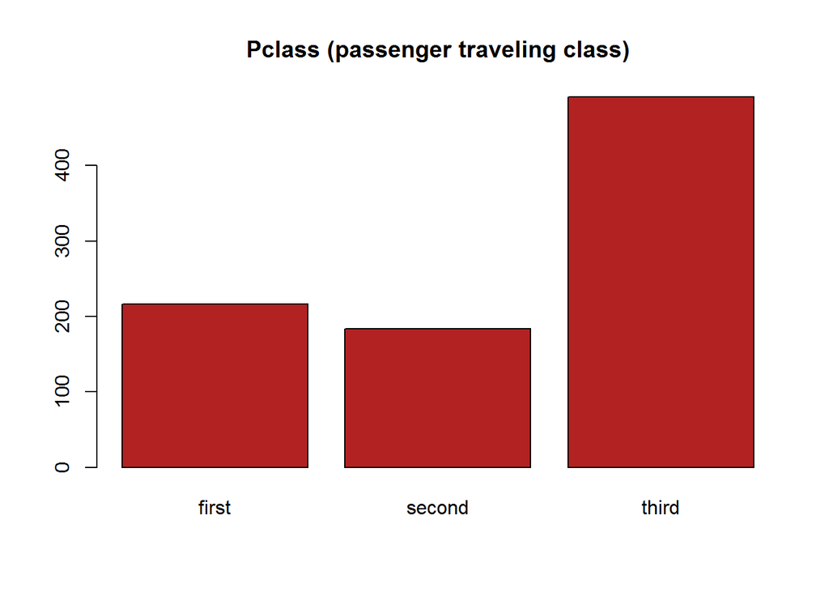

```r
barplot(table(df.train$Pclass),
        names.arg = c("first", "second", "third"),
        main="Pclass (passenger traveling class)", col="firebrick")
```

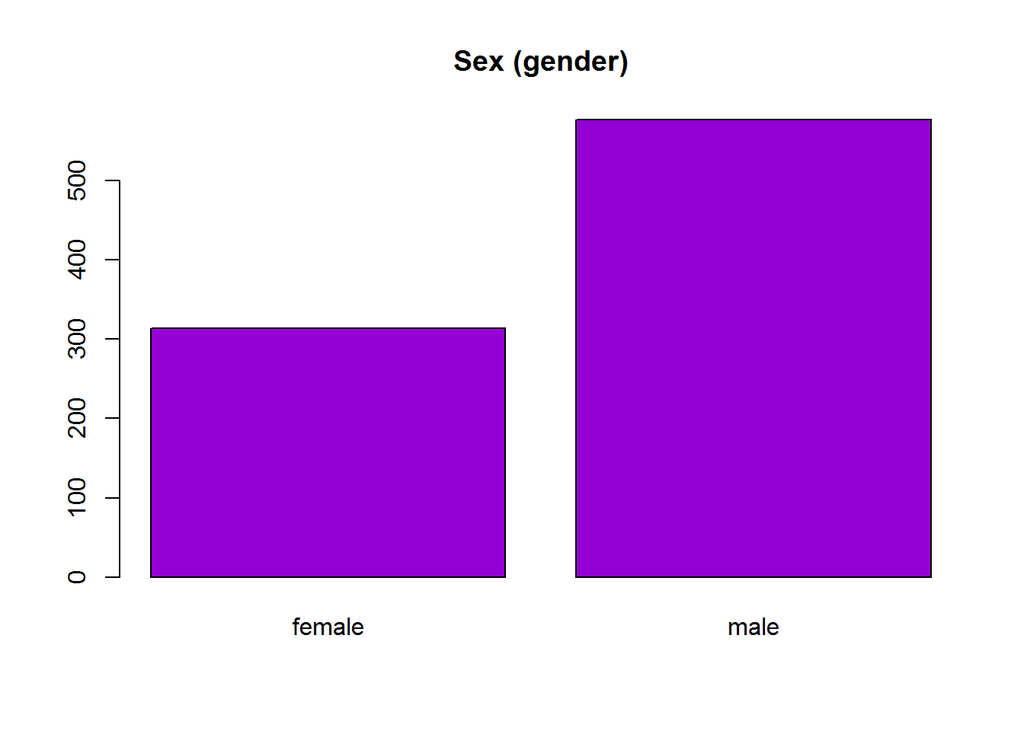

```r
barplot(table(df.train$Sex), main="Sex (gender)", col="darkviolet")
```

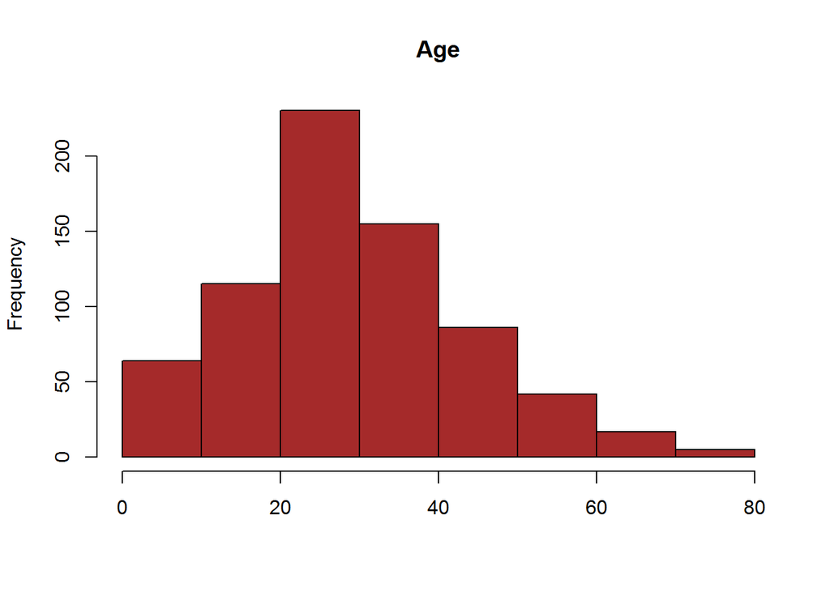

```r
hist(df.train$Age, main="Age", xlab = NULL, col="brown")
```

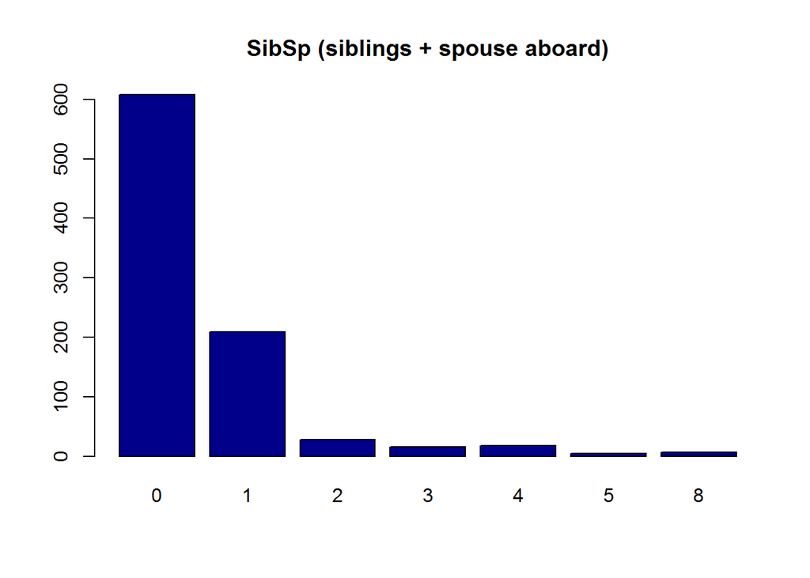

```r
barplot(table(df.train$SibSp), main="SibSp (siblings + spouse aboard)",
        col="darkblue")
```

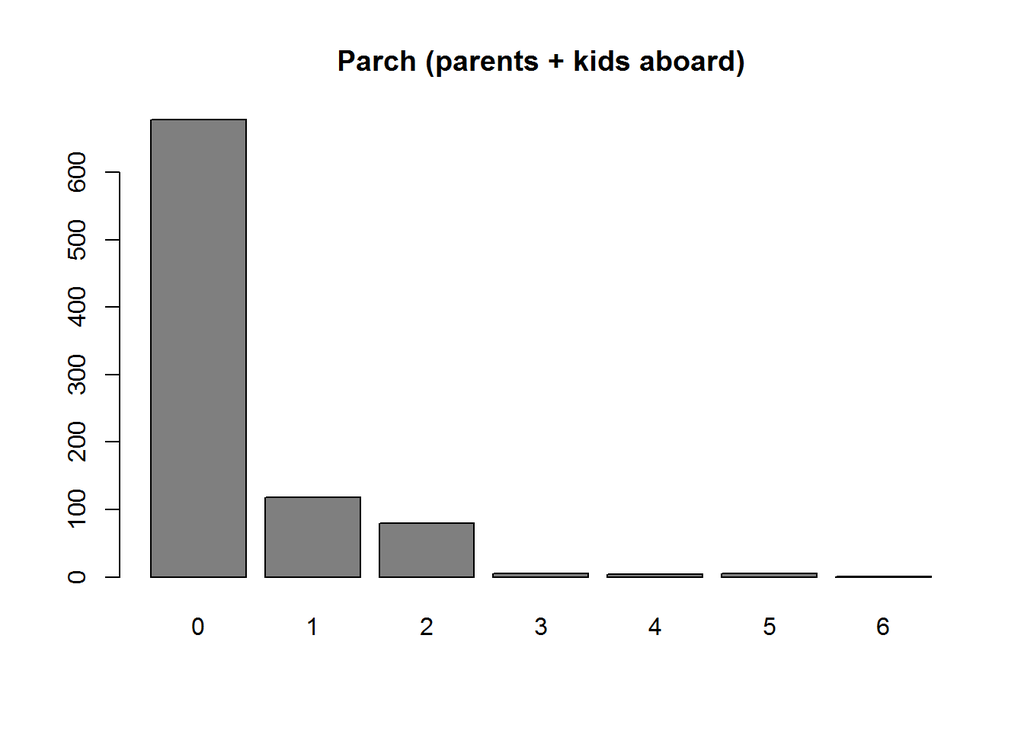

```r
barplot(table(df.train$Parch), main="Parch (parents + kids aboard)",
        col="gray50")
```

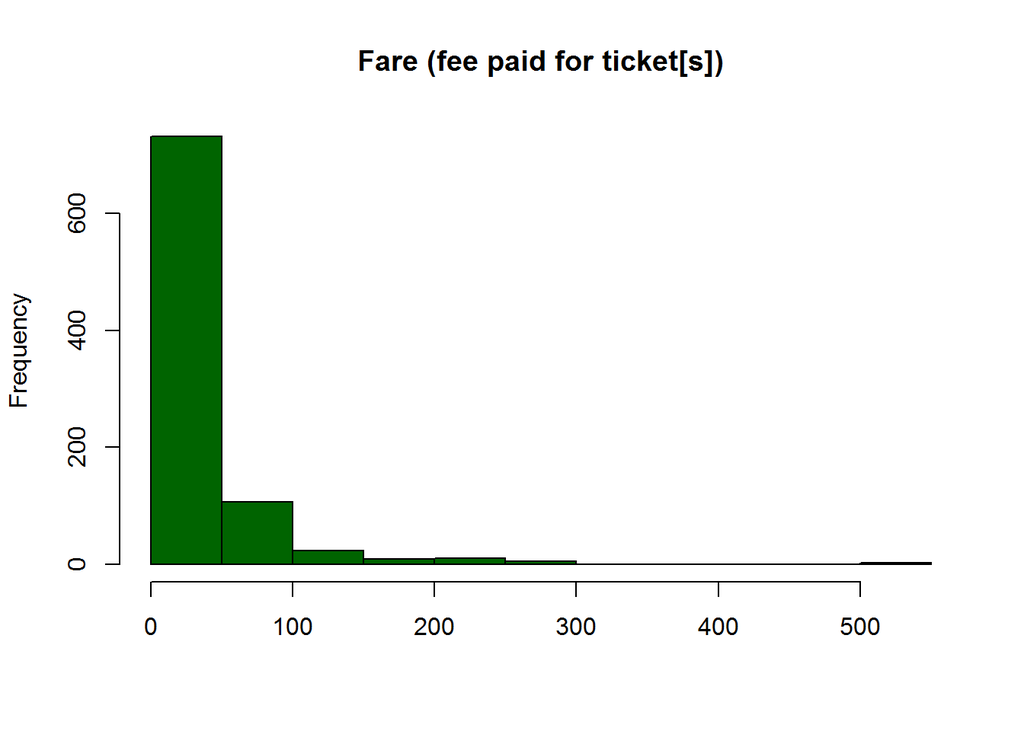

```r
hist(df.train$Fare, main="Fare (fee paid for ticket[s])", xlab = NULL,
     col="darkgreen")
```

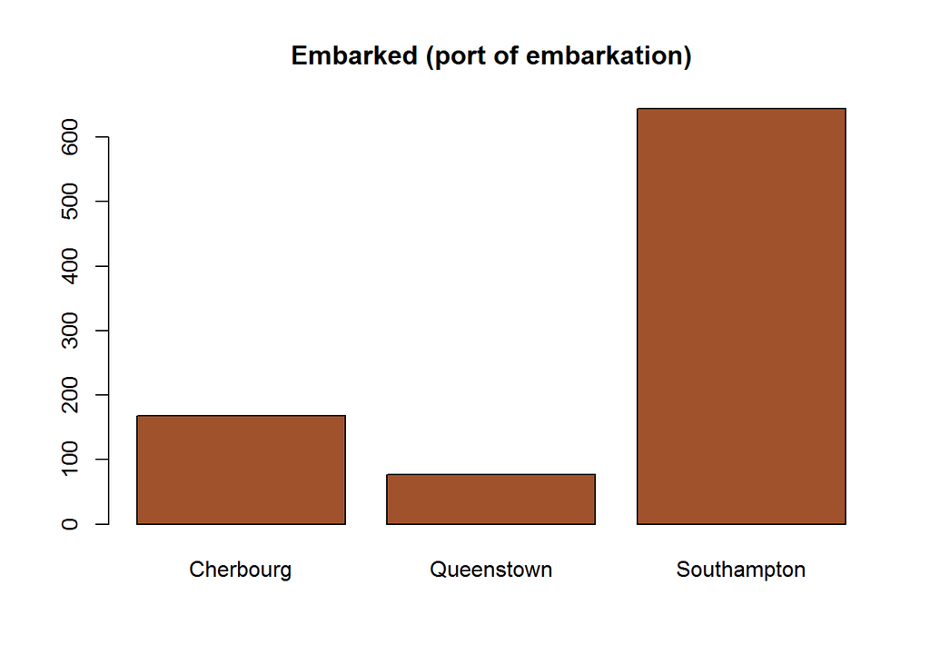

```r
barplot(table(df.train$Embarked),
        names.arg = c("Cherbourg", "Queenstown", "Southampton"),
        main="Embarked (port of embarkation)", col="sienna")
```

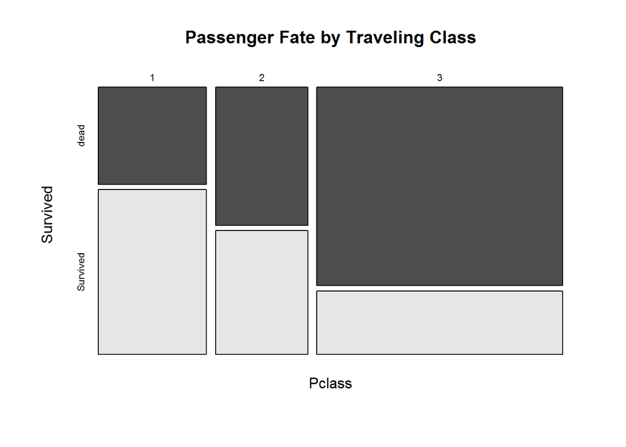

```r
mosaicplot(df.train$Pclass ~ df.train$Survived,
           main="Passenger Fate by Traveling Class", shade=FALSE,
           color=TRUE, xlab="Pclass", ylab="Survived")
```

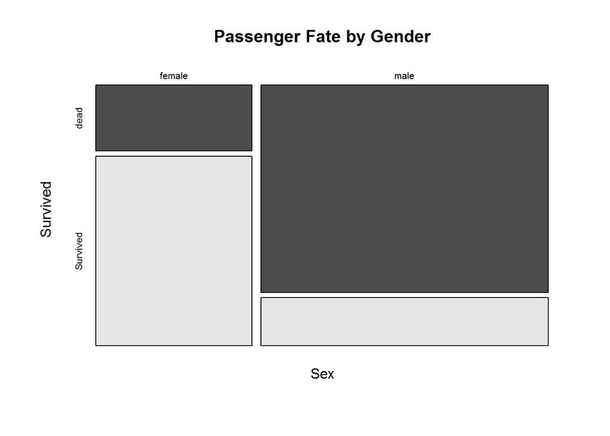

```r
mosaicplot(df.train$Sex ~ df.train$Survived,
             main="Passenger Fate by Gender", shade=FALSE, color=TRUE,
             xlab="Sex", ylab="Survived")
```

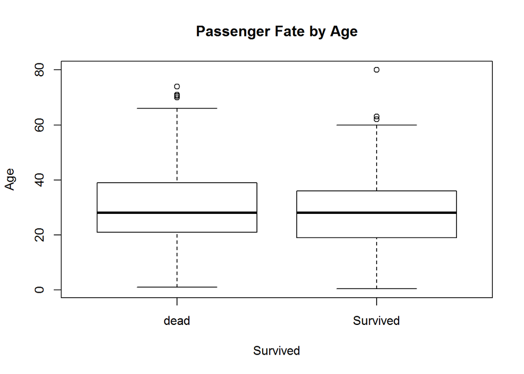

```r
boxplot(df.train$Age ~ df.train$Survived,
        main="Passenger Fate by Age",
        xlab="Survived", ylab="Age")
```

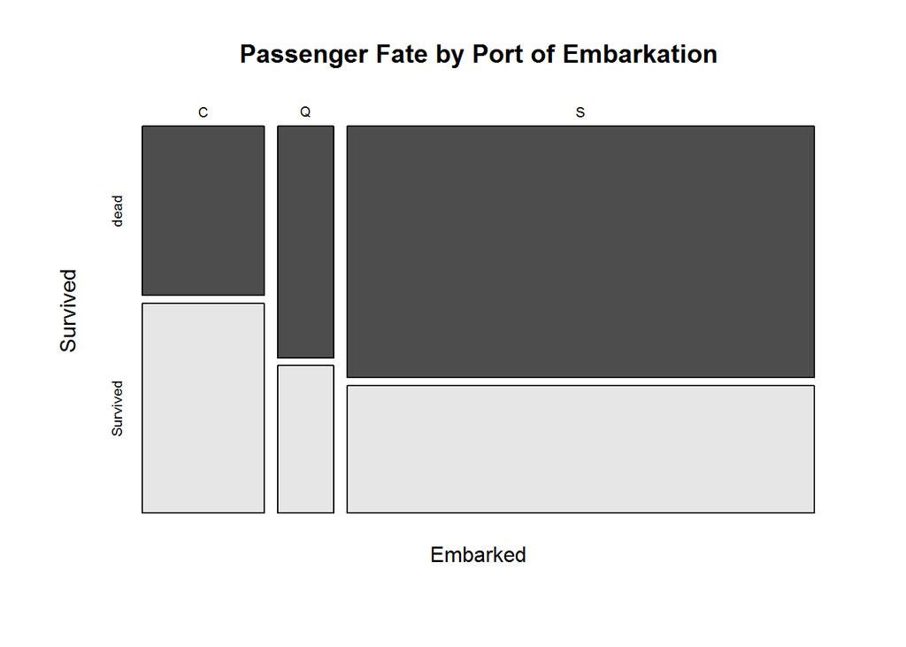

```r
mosaicplot(df.train$Embarked ~ df.train$Survived,
           main="Passenger Fate by Port of Embarkation",
           shade=FALSE, color=TRUE, xlab="Embarked", ylab="Survived")
```

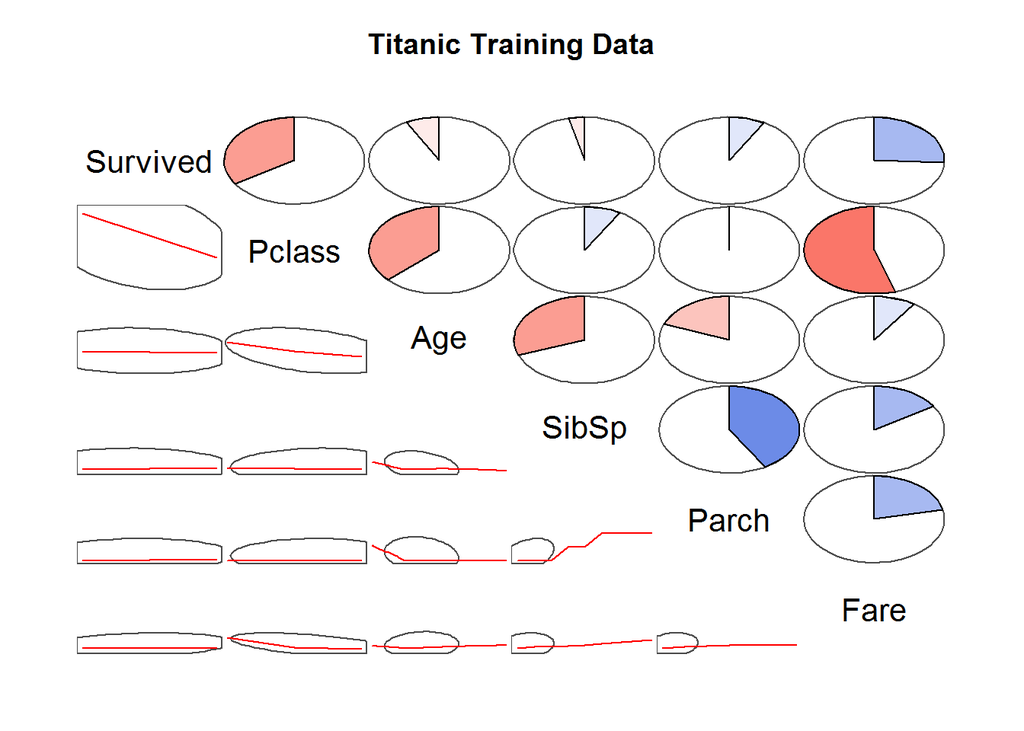

```r
# install.packages("corrgram")
require(corrgram)
require(plyr)
corrgram.data <- df.train
## change features of factor type to numeric type for inclusion on correlogram
corrgram.data$Survived <- as.numeric(corrgram.data$Survived)
corrgram.data$Pclass <- as.numeric(corrgram.data$Pclass)
corrgram.data$Embarked <- revalue(corrgram.data$Embarked, c("C" = 1, "Q" = 2, "S" = 3))
## generate correlogram
corrgram.vars <- c("Survived", "Pclass", "Sex", "Age", "SibSp", "Parch", "Fare", "Embarked")
corrgram(corrgram.data[,corrgram.vars], order=FALSE,
         lower.panel=panel.ellipse, upper.panel=panel.pie,
         text.panel=panel.txt, main="Titanic Training Data")
```

```r
# summary(df.train$Age)
# names(df.train)
```

## 간단한 모델 적용

이 절에서는 기계학습 모델을 적용해 보고자 함 여기서는 의사결정 나무 모델(rpart) 와 조건부 추론 나무(ctree) 를 사용함

이유는 .. 쉽고 .. 다양한 변수의 상호 작용을 잘 표현해 주며,  
NA 값에 대한 대리 변수 처리가 잘 되기 때문임

### 평가 메트릭

탑승객 생존 여부 예측 모델의 성능은 정확도(accuracy) 로 하기로 함  
예측값과 실제값의 정확도는 아래와 같이 계산 (예시)

```r
predicted <- c(1,0,0,1,1)
actual <- c(1,0,0,0,0)
sum(predicted == actual) / NROW(predicted)
```

```
## [1] 0.6
```

### 홀드아웃 기법

- 일반적으로 훈련, 테스트, 검증은 50:25:25 로 나눔
- 여기서는 데이터가 많지 않기 때문에 훈련:테스트, 80:20 으로 나눔
- caret::createDataPartition() 함수를 사용함

```r
# install.packages("caret")
suppressPackageStartupMessages({
  library(caret)
})
set.seed(23)
training.rows <- createDataPartition(df.train$Survived,  p = 0.8, list = FALSE)
train.batch <- df.train[training.rows, ]
test.batch <- df.train[-training.rows, ]
```

### 의사결정나무

```r
suppressPackageStartupMessages({
  library(rpart)
})


m <- rpart(
  Survived ~ Pclass + Sex + Age + SibSp + Parch + Fare + Embarked,
  data = train.batch
  )

## 훈련 데이터 기반
p_rtree <- predict(m, newdata=test.batch, type="class")
rpart_result <- list(actual=test.batch$Survived, predicted=p_rtree)
head(rpart_result)
```

```
## $actual
##   [1] dead     Survived Survived dead     Survived dead     dead     dead     dead     dead     dead     dead     dead     dead     Survived Survived
##  [17] dead     Survived Survived dead     dead     Survived Survived dead     dead     dead     dead     dead     Survived Survived dead     dead
##  [33] dead     Survived dead     dead     dead     dead     dead     dead     dead     dead     Survived Survived Survived Survived dead     Survived
##  [49] Survived Survived dead     dead     Survived Survived dead     dead     Survived Survived dead     dead     dead     dead     dead     dead
##  [65] dead     dead     dead     dead     Survived Survived dead     Survived Survived dead     dead     Survived Survived dead     Survived dead
##  [81] dead     dead     Survived Survived Survived dead     Survived dead     Survived dead     Survived dead     dead     dead     dead     Survived
##  [97] Survived dead     Survived dead     dead     dead     Survived dead     dead     dead     dead     Survived Survived dead     dead     dead
## [113] Survived dead     dead     dead     Survived Survived Survived dead     dead     Survived Survived Survived dead     dead     dead     Survived
## [129] Survived dead     dead     dead     Survived dead     dead     dead     Survived dead     dead     Survived dead     dead     Survived dead
## [145] dead     dead     dead     dead     Survived Survived dead     dead     dead     Survived Survived dead     dead     dead     dead     dead
## [161] dead     dead     Survived Survived dead     Survived Survived Survived dead     dead     dead     dead     Survived Survived Survived Survived
## [177] dead
## Levels: dead Survived
##
## $predicted
##        1       10       11       13       22       27       30       35       39       41       42       46       49       52       56       57
##     dead Survived Survived     dead     dead     dead     dead     dead Survived     dead Survived     dead     dead     dead     dead Survived
##       58       59       67       77       78       79       80       92       94      106      116      121      124      126      130      131
##     dead Survived Survived     dead     dead Survived     dead     dead     dead     dead     dead     dead Survived Survived     dead     dead
##      135      137      140      151      154      164      170      181      186      204      205      208      209      212      213      219
##     dead Survived     dead     dead     dead     dead     dead     dead     dead     dead     dead     dead Survived Survived     dead Survived
##      221      225      237      243      248      249      253      254      256      260      265      274      279      283      288      296
##     dead     dead     dead     dead Survived     dead     dead     dead     dead Survived Survived     dead     dead     dead     dead     dead
##      298      305      309      315      317      319      322      330      331      332      337      338      339      340      342      344
## Survived     dead     dead     dead Survived Survived     dead Survived Survived     dead     dead Survived     dead     dead Survived     dead
##      350      353      357      367      369      374      377      386      388      397      408      419      420      421      439      441
##     dead     dead Survived Survived Survived     dead Survived     dead Survived     dead Survived     dead Survived     dead     dead Survived
##      458      466      474      476      482      483      487      488      491      503      509      517      519      520      525      543
## Survived     dead Survived     dead     dead     dead Survived     dead     dead Survived     dead Survived Survived     dead     dead     dead
##      547      553      563      569      570      571      578      583      585      586      588      592      603      604      611      616
## Survived     dead     dead     dead     dead     dead Survived     dead     dead Survived     dead Survived     dead     dead     dead Survived
##      619      629      630      637      652      653      659      666      671      675      676      678      679      681      682      689
## Survived     dead     dead     dead Survived     dead     dead     dead Survived     dead     dead     dead     dead Survived     dead     dead
##      694      699      700      706      718      728      732      754      762      764      766      776      784      790      792      795
##     dead     dead     dead     dead Survived Survived Survived     dead     dead Survived Survived     dead Survived     dead     dead     dead
##      817      818      821      822      826      830      831      832      841      846      851      855      856      857      866      867
##     dead     dead Survived     dead     dead Survived     dead Survived     dead     dead     dead Survived     dead Survived Survived Survived
##      889
## Survived
## Levels: dead Survived
```

```r
## 정확도 평가
sum(rpart_result$predicted == rpart_result$actual) / NROW(rpart_result$actual)  # 10겹 교차는 뒤쪽에서 진행, 그때 정확도도 평균, 표준편차를 표시, 밀도그림도 .. 뒤쪽에서 보여줘야 겠고
```

```
## [1] 0.8361582
```

```r
# @@@ 제출용 코드
# names(all2)
# all2$Survived <- predict(m, newdata=all2, type="class")
# all2$Survived <- revalue(all2$Survived, c("Survived" = 1, "dead" = 0))
# head(all2)
# submission_01 <- all2[,c("PassengerId", "Survived")]
# setwd("C:\\Users\\user\\Documents\\eda\\submission")
# getwd()
# write.csv(submission_01, file = "test_decistion_tree_01.csv", row.names=FALSE)
```

### 조건부의사결정나무

```r
suppressPackageStartupMessages({
  library(party)
})
model_ctree <- ctree(
  Survived ~ Pclass + Sex + Age + SibSp + Parch + Fare + Embarked,
  data = train.batch
)

# predicted2  <- predict(model_rpart, newdata=df.train, type="class")
# cpart_result <- list(actual=df.train$Survived, predicted=predicted2)

## 훈련 데이터 기반
p_ctree <- predict(model_ctree, newdata=test.batch, type="response")
ctree_result <- list(actual=test.batch$Survived, predicted=p_ctree)
head(ctree_result)
```

```
## $actual
##   [1] dead     Survived Survived dead     Survived dead     dead     dead     dead     dead     dead     dead     dead     dead     Survived Survived
##  [17] dead     Survived Survived dead     dead     Survived Survived dead     dead     dead     dead     dead     Survived Survived dead     dead
##  [33] dead     Survived dead     dead     dead     dead     dead     dead     dead     dead     Survived Survived Survived Survived dead     Survived
##  [49] Survived Survived dead     dead     Survived Survived dead     dead     Survived Survived dead     dead     dead     dead     dead     dead
##  [65] dead     dead     dead     dead     Survived Survived dead     Survived Survived dead     dead     Survived Survived dead     Survived dead
##  [81] dead     dead     Survived Survived Survived dead     Survived dead     Survived dead     Survived dead     dead     dead     dead     Survived
##  [97] Survived dead     Survived dead     dead     dead     Survived dead     dead     dead     dead     Survived Survived dead     dead     dead
## [113] Survived dead     dead     dead     Survived Survived Survived dead     dead     Survived Survived Survived dead     dead     dead     Survived
## [129] Survived dead     dead     dead     Survived dead     dead     dead     Survived dead     dead     Survived dead     dead     Survived dead
## [145] dead     dead     dead     dead     Survived Survived dead     dead     dead     Survived Survived dead     dead     dead     dead     dead
## [161] dead     dead     Survived Survived dead     Survived Survived Survived dead     dead     dead     dead     Survived Survived Survived Survived
## [177] dead
## Levels: dead Survived
##
## $predicted
##   [1] dead     Survived Survived dead     dead     dead     dead     dead     Survived Survived Survived dead     dead     dead     dead     Survived
##  [17] dead     Survived Survived dead     dead     Survived Survived dead     dead     dead     dead     dead     Survived dead     dead     dead
##  [33] dead     Survived dead     dead     dead     dead     dead     dead     dead     dead     dead     dead     Survived Survived dead     Survived
##  [49] dead     dead     dead     dead     Survived dead     dead     dead     Survived Survived Survived dead     dead     dead     dead     dead
##  [65] Survived dead     dead     dead     Survived Survived dead     Survived Survived dead     dead     Survived dead     dead     Survived dead
##  [81] dead     dead     Survived Survived Survived dead     Survived dead     Survived Survived Survived dead     Survived dead     dead     Survived
##  [97] Survived dead     Survived dead     dead     dead     Survived dead     dead     Survived dead     Survived Survived dead     dead     dead
## [113] Survived dead     dead     dead     dead     dead     Survived dead     dead     Survived dead     Survived dead     dead     dead     Survived
## [129] Survived dead     dead     dead     Survived dead     dead     dead     Survived dead     dead     Survived dead     Survived dead     dead
## [145] dead     dead     dead     dead     Survived Survived dead     dead     dead     Survived Survived dead     dead     dead     dead     dead
## [161] Survived dead     Survived dead     dead     Survived Survived Survived dead     dead     dead     Survived Survived Survived Survived Survived
## [177] Survived
## Levels: dead Survived
```

```r
## 정확도 평가
sum(ctree_result$predicted == ctree_result$actual) / NROW(ctree_result$actual)  # 10겹 교차는 뒤쪽에서 진행, 그때 정확도도 평균, 표준편차를 표시
```

```
## [1] 0.8531073
```

> rpart 대비 성능이 향상되었음

### 가설생성과 가설 검증을 통한 모델 피팅

1. 가설을 생성
   - 데이터 탐색을 통하여 데이터의특성들을 확인할 수 있었음
   - 이러한 데이터를 바탕으로 이 분야의 도메인 지식(knowledge)를 활용하여 새로운 가설을 생서함
2. 가설에 필요한 Feature를 추출
   - 1 에서 생성한 새로운 가설의 검증하기 위하여 필요한 Feature들을 가지고 있는 정보 내에서 추출함(extract)
3. 가설을 검증
   - 2 에서 생성된 Feature를 이용하여 1 에서 세운 가설이 맞는지 가설을 검증(hypothesis testing)함

### 가설을 생성

1. 가설 1 “가족과의 관계가 생존에 영향을 주었을 것이다.”
   - 타이타닉 영화를 보면 OOO이 살기위해 모르는 딸아이의 아빠인척을 하는 장면이 나온다.
   - 이처럼 가족의 생존확률이 높으면 자신의 생존 확률이 높을 것이라고 추정해 볼 수 있다.
2. 가설 2 “아이와 여자가 생존 확률이 높았을 것이다.”
   - 타이타닉의 영화를 보면 보트에 아이와 여자를 먼저 태우는 장면을 볼 수 있다.
   - 이처럼 위급한 상황에서 아이와 여자들을 위하여 보트에 탑승을 양보했을 것이라고 추청할 수 있다.
3. 가설 3 “구명 보트에 가까이 있는 탑승자가 생존 확률이 높았을 것이다.”
   - 보트는 제한된 수량만이 탐제가 되었다. 이는 타이타닉의 탑승객이 전부 탑승 할 수 없음을 의미하며,
   - 보트에 빠르게 탑승한 인원이 좀 더 생존확률이 높았을 것이라고 추정해 볼 수 있다.

여기서는 첫번째와 두번째 가설을 동시에 확인해 볼 예정이다.

### 가설에 필요한 Feature를 추출

- 가족관계를 알기위해 ticket 을 사용한 가족 식별
  - 한 가족이 표를 샀다면 티켓 번호가 같을 것이다.
  - 티켓 가격정보도 가족수만큼 1/n 해서 정상화함
- 부모의 생존확률과 자녀의 평균 생존 확률을 파악
  - 앞에서 부모 자녀 여부를 판단하고 나면 부모의 평균 생존 확률(avg_parent_prob)과 자녀의 평균 생존 확률을 구함
- Age의 null 값을 가족 관계를 통하여유추함
  - 이름을 앞자리를 통하여 과족관계시의 나이를 유추
  - 자식의 나이는 부모보다 높을 수 없다. 또한 이름을 통하여 나이를 어느정도 유추가 가능하다.

| Title | 설명 |
| --- | --- |
| Mr: (Mister) | (Mister) for men, regardless of marital status. |
| Master | for young men and boys, especially in the UK. |
| Ms | for women, regardless of marital status. |
| Mz | variation of Ms., used for women who do not wish to disclose their marital status. |
| Miss | usually for unmarried women |
| Mrs | for married women. |
| Mx | is a commonly accepted gender-neutral honorific. |

- Embarked 필드는 제일 많은 S 값으로 채워줌

주의할 점은 앞서 훈련, 테스트를 분리한 것을 합쳐서 사용함, 전체 데이터를 가지고 처리 및 feature 분리를 할 것임

```r
suppressPackageStartupMessages({
  library(plyr)
})


  train.batch$type <- "T"
  test.batch$type <- "V"
  all <- rbind(train.batch, test.batch)  ## ticket 을 통해 가족ID를 부여하기 위해 훈련데이터와 테스트 데이터를 합침

  ## mbarked 필드는 제일 많은 S 값으로 채워줌
  summary(all$Embarked)
```

```
##    C    Q    S NA's
##  168   77  644    2
```

```r
  all$Embarked[which(is.na(all$Embarked))] <- 'S'



### 당초 타이틀을 통해 나이 등을 유추하는 것 추가
### 기존 대비 차이점은 all  상태에서 처리를

head(df.train$Name, n=10L)
```

```
##  [1] "Braund, Mr. Owen Harris"                             "Cumings, Mrs. John Bradley (Florence Briggs Thayer)"
##  [3] "Heikkinen, Miss. Laina"                              "Futrelle, Mrs. Jacques Heath (Lily May Peel)"
##  [5] "Allen, Mr. William Henry"                            "Moran, Mr. James"
##  [7] "McCarthy, Mr. Timothy J"                             "Palsson, Master. Gosta Leonard"
##  [9] "Johnson, Mrs. Oscar W (Elisabeth Vilhelmina Berg)"   "Nasser, Mrs. Nicholas (Adele Achem)"
```

```r
getTitle <- function(data) {
  title.dot.start <- regexpr("\\,[A-Z ]{1,20}\\.", data$Name, TRUE)
  title.comma.end <- title.dot.start + attr(title.dot.start, "match.length")-1  ## copy&paste 시 중간 공백주의 필요
  data$Title <- substr(data$Name, title.dot.start+2, title.comma.end-1)
  return(data$Title)
}


 all$Title <- getTitle(all)
 unique(all$Title)
```

```
##  [1] "Mrs"          "Miss"         "Mr"           "Master"       "Don"          "Rev"          "Dr"           "Mme"          "Ms"
## [10] "Major"        "Lady"         "Sir"          "Mlle"         "Col"          "Capt"         "the Countess" "Jonkheer"
```

```r
options(digits=2)
require(Hmisc)
bystats(all$Age, all$Title,
        fun=function(x)c(Mean=mean(x),Median=median(x)))
```

```
##
##  c(35, 13, 35, 55, 13, 55, 35, 35) of all$Age by all$Title
##
##                N Missing Mean Median
## Capt           1       0 70.0   70.0
## Col            2       0 58.0   58.0
## Don            1       0 40.0   40.0
## Dr             6       1 42.0   46.5
## Jonkheer       1       0 38.0   38.0
## Lady           1       0 48.0   48.0
## Major          2       0 48.5   48.5
## Master        36       4  4.6    3.5
## Miss         146      36 21.8   21.0
## Mlle           2       0 24.0   24.0
## Mme            1       0 24.0   24.0
## Mr           398     119 32.4   30.0
## Mrs          108      17 35.9   35.0
## Ms             1       0 28.0   28.0
## Rev            6       0 43.2   46.5
## Sir            1       0 49.0   49.0
## the Countess   1       0 33.0   33.0
## ALL          714     177 29.7   28.0
```

```r
titles.na.train <- c("Dr", "Master", "Mrs", "Miss", "Mr")


imputeMedian <- function(impute.var, filter.var, var.levels) {
  for(v in var.levels) {
    impute.var[which(filter.var == v)] <- impute(impute.var[which(filter.var == v)])
  }
  return(impute.var)
}

all$Age[which(all$Title=="Dr")]
```

```
## [1] 44 54 23 32 50 NA 49
```

```r
all$Age <- imputeMedian(all$Age, all$Title, titles.na.train)
all$Age[which(all$Title=="Dr")]
```

```
## [1] 44 54 23 32 50 46 49
```

```r
subset(all, Fare < 7)[order(subset(all, Fare < 7)$Fare,
                          subset(all, Fare < 7)$Pclass), c("Age", "Title", "Pclass", "Fare")]
```

```
##     Age    Title Pclass Fare
## 264  40       Mr      1  0.0
## 634  30       Mr      1  0.0
## 807  39       Mr      1  0.0
## 816  30       Mr      1  0.0
## 823  38 Jonkheer      1  0.0
## 278  30       Mr      2  0.0
## 414  30       Mr      2  0.0
## 467  30       Mr      2  0.0
## 733  30       Mr      2  0.0
## 482  30       Mr      2  0.0
## 675  30       Mr      2  0.0
## 180  36       Mr      3  0.0
## 272  25       Mr      3  0.0
## 303  19       Mr      3  0.0
## 598  49       Mr      3  0.0
## 379  20       Mr      3  4.0
## 873  33       Mr      1  5.0
## 327  61       Mr      3  6.2
## 844  34       Mr      3  6.4
## 819  43       Mr      3  6.4
## 203  34       Mr      3  6.5
## 372  18       Mr      3  6.5
## 144  19       Mr      3  6.8
## 655  18     Miss      3  6.8
## 412  30       Mr      3  6.9
## 826  30       Mr      3  7.0
## 805  27       Mr      3  7.0
## 130  45       Mr      3  7.0
```

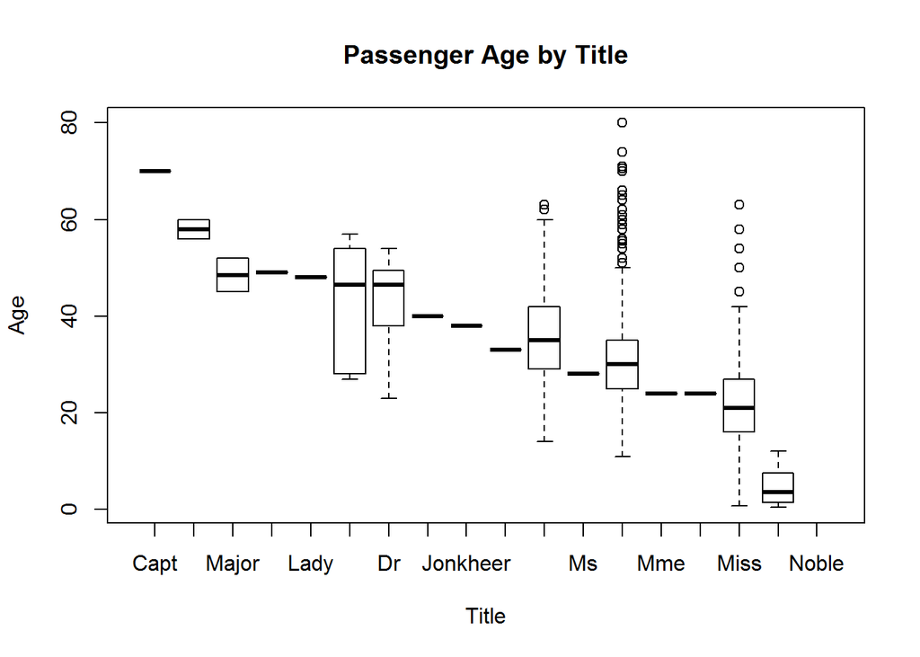

```r
## impute missings on Fare feature with median fare by Pclass
all$Fare[ which(all$Fare == 0)] <- NA
all$Fare <- imputeMedian(all$Fare, all$Pclass, as.numeric(levels(all$Pclass)))

all$Title <- factor(all$Title,c("Capt","Col","Major","Sir","Lady","Rev","Dr","Don","Jonkheer","the Countess","Mrs","Ms","Mr","Mme","Mlle","Miss","Master","Noble"))   ##Noble 를 추가해줌
# head(all[,c("Age", "Title")], n=100)
boxplot(all$Age ~ all$Title,
        main="Passenger Age by Title", xlab="Title", ylab="Age")
```

```r
## function for assigning a new title value to old title(s)
changeTitles <- function(data, old.titles, new.title) {
  for(honorific in old.titles) {
    data$Title[which(data$Title == honorific)] <- new.title
  }
  return(data$Title)
}

str(all)
```

```
## 'data.frame':    891 obs. of  14 variables:
##  $ PassengerId: int  2 3 4 5 6 7 8 9 12 14 ...
##  $ Survived   : Factor w/ 2 levels "dead","Survived": 2 2 2 1 1 1 1 2 2 1 ...
##  $ Pclass     : Factor w/ 3 levels "1","2","3": 1 3 1 3 3 1 3 3 1 3 ...
##  $ Name       : chr  "Cumings, Mrs. John Bradley (Florence Briggs Thayer)" "Heikkinen, Miss. Laina" "Futrelle, Mrs. Jacques Heath (Lily May Peel)" "Allen, Mr. William Henry" ...
##  $ Sex        : Factor w/ 2 levels "female","male": 1 1 1 2 2 2 2 1 1 2 ...
##  $ Age        : num  38 26 35 35 30 54 2 27 58 39 ...
##  $ SibSp      : int  1 0 1 0 0 0 3 0 0 1 ...
##  $ Parch      : int  0 0 0 0 0 0 1 2 0 5 ...
##  $ Ticket     : chr  "PC 17599" "STON/O2. 3101282" "113803" "373450" ...
##  $ Fare       : num  71.28 7.92 53.1 8.05 8.46 ...
##  $ Cabin      : chr  "C85" NA "C123" NA ...
##  $ Embarked   : Factor w/ 3 levels "C","Q","S": 1 3 3 3 2 3 3 3 3 3 ...
##  $ type       : chr  "T" "T" "T" "T" ...
##  $ Title      : Factor w/ 18 levels "Capt","Col","Major",..: 11 16 11 13 13 13 17 11 16 13 ...
```

```r
levels(all$Title)
```

```
##  [1] "Capt"         "Col"          "Major"        "Sir"          "Lady"         "Rev"          "Dr"           "Don"          "Jonkheer"
## [10] "the Countess" "Mrs"          "Ms"           "Mr"           "Mme"          "Mlle"         "Miss"         "Master"       "Noble"
```

```r
## Title consolidation
all$Title <- changeTitles(all, c("Capt", "Col", "Don", "Dr", "Jonkheer", "Lady", "Major", "Rev", "Sir"),"Noble")
all$Title <- changeTitles(all, c("the Countess", "Ms"), "Mrs")
all$Title <- changeTitles(all, c("Mlle", "Mme"), "Miss")
all$Title <- as.factor(all$Title)

require(plyr)     # for the revalue function
require(stringr)  # for the str_sub function
## test a character as an EVEN single digit
isEven <- function(x) x %in% c("0","2","4","6","8")
## test a character as an ODD single digit
isOdd <- function(x) x %in% c("1","3","5","7","9")

## function to add features to training or test data frames
featureEngrg <- function(data) {
  ## Using Fate ILO Survived because term is shorter and just sounds good
  data$Fate <- data$Survived
  ## Revaluing Fate factor to ease assessment of confusion matrices later
  data$Fate <- revalue(data$Fate, c("1" = "Survived", "0" = "Perished"))
  ## Boat.dibs attempts to capture the "women and children first"
  ## policy in one feature.  Assuming all females plus males under 15
  ## got "dibs' on access to a lifeboat
  data$Boat.dibs <- "No"
  data$Boat.dibs[which(data$Sex == "female" | data$Age < 15)] <- "Yes"
  data$Boat.dibs <- as.factor(data$Boat.dibs)
  ## Family consolidates siblings and spouses (SibSp) plus
  ## parents and children (Parch) into one feature
  data$Family <- data$SibSp + data$Parch
  ## Fare.pp attempts to adjust group purchases by size of family
  data$Fare.pp <- data$Fare/(data$Family + 1)
  ## Giving the traveling class feature a new look
  data$Class <- data$Pclass
  data$Class <- revalue(data$Class,
                        c("1"="First", "2"="Second", "3"="Third"))
  ## First character in Cabin number represents the Deck
  data$Deck <- substring(data$Cabin, 1, 1)
  data$Deck[ which( is.na(data$Deck ))] <- "UNK"
  data$Deck <- as.factor(data$Deck)
  ## Odd-numbered cabins were reportedly on the port side of the ship
  ## Even-numbered cabins assigned Side="starboard"
  data$cabin.last.digit <- str_sub(data$Cabin, -1)
  data$Side <- "UNK"
  data$Side[which(isEven(data$cabin.last.digit))] <- "port"
  data$Side[which(isOdd(data$cabin.last.digit))] <- "starboard"
  data$Side <- as.factor(data$Side)
  data$cabin.last.digit <- NULL
  return(data)
}

## add remaining features to training data frame
all <- featureEngrg(all)
  summary(all$Fare)  ## 이 정보와 앞서 EDA쪽을 연결시킴
```

```
##    Min. 1st Qu.  Median    Mean 3rd Qu.    Max.
##       4       8      14      33      31     512
```

```r
  ctree_model <- ctree(Survived ~ Pclass + Sex + Age + SibSp + Parch + Fare + Embarked,data = all)

#   all <- df.train

  all$prob <- sapply(predict(ctree_model,type="prob", newdata=all), function(result){ result[1]})
  head(all)
```

```
##   PassengerId Survived Pclass                                                Name    Sex Age SibSp Parch           Ticket Fare Cabin Embarked type
## 2           2 Survived      1 Cumings, Mrs. John Bradley (Florence Briggs Thayer) female  38     1     0         PC 17599 71.3   C85        C    T
## 3           3 Survived      3                              Heikkinen, Miss. Laina female  26     0     0 STON/O2. 3101282  7.9  <NA>        S    T
## 4           4 Survived      1        Futrelle, Mrs. Jacques Heath (Lily May Peel) female  35     1     0           113803 53.1  C123        S    T
## 5           5     dead      3                            Allen, Mr. William Henry   male  35     0     0           373450  8.1  <NA>        S    T
## 6           6     dead      3                                    Moran, Mr. James   male  30     0     0           330877  8.5  <NA>        Q    T
## 7           7     dead      1                             McCarthy, Mr. Timothy J   male  54     0     0            17463 51.9   E46        S    T
##   Title     Fate Boat.dibs Family Fare.pp Class Deck      Side  prob
## 2   Mrs Survived       Yes      1    35.6 First    C starboard 0.053
## 3  Miss Survived       Yes      0     7.9 Third  UNK       UNK 0.410
## 4   Mrs Survived       Yes      1    26.6 First    C starboard 0.053
## 5    Mr     dead        No      0     8.1 Third  UNK       UNK 0.893
## 6    Mr     dead        No      0     8.5 Third  UNK       UNK 0.893
## 7    Mr     dead        No      0    51.9 First    E      port 0.631
```

```r
  ## 티켓 번호를 사용한 family_id
  family_idx <- 0
  ## 같은Ticket 값을 갖는 행끼리 그룹핑 , 번호를 부여해줌
  ticket_based_family_id <- ddply(all, .(Ticket), function(rows) {
    family_idx <<- family_idx +1
    return(data.frame(family_id=paste0("TICKET_", family_idx)))
  })


  all <- adply(all
    , 1
    , function(row) {
        family_id <- NA
        if(!is.na(row$Ticket)) {
          family_id <- subset(ticket_based_family_id, Ticket == row$Ticket)$family_id
        }
        return(data.frame(family_id=family_id))
      })

  ### avg_prob 를 구함
  all <- ddply(all,
      .(family_id)
      , function(rows){
          rows$avg_prob <- mean(rows$prob)
          return(rows)
      })


  ### 탑승객이 부모 또는 자녀 중 어느 쪽에 속하는지를 알아봄
  ### 판단 기준은 나이를 사용

  all <- ddply(all, .(family_id), function(rows){
            rows$maybe_parent <- FALSE
            rows$maybe_child <- FALSE
            if(NROW(rows) == 1 || ## 1명이면 부모도 자녀도 아님
              sum(rows$Parch) == 0 || ## 역시 부모도 자녀도 아님
              NROW(rows) == sum(is.na(rows$Age))){ ## 행에 나이가 저장되어 있지 않으면 알 수 없음
              return (rows)
            }

            max_age <- max(rows$Age, na.rm=TRUE)
            min_age <- min(rows$Age, na.rm=TRUE)

            ## 부모인지 , 자녀인지
            return(adply(rows, 1, function(row){
              if(!is.na(row$Age) && !is.na(row$Sex)) {
                row$maybe_parent <- (max_age - row$Age) < 10 ## > 로 되어야 하는 것 아닌가?
                row$maybe_child <- (row$Age - min_age) < 10
              }
              return(row)
          }))

        })

  ## avg_parent_prob , avg_child_prob
  all <- ddply(all, .(family_id), function(rows) {
              rows$avg_parent_prob <- rows$avg_prob ## 기본값은 가족의 평균 생존 확률
              rows$avg_child_prob <- rows$avg_prob ## 기본값은 가족의 평균 생존 확률
              if(NROW(rows) == 1 || sum(rows$Parch) == 0 ) {
                return(rows)
               }
              parent_prob <- subset(rows, maybe_parent == TRUE)[,"prob"]
              if(NROW(parent_prob) > 0 ) {
                  rows$avg_parent_prob <- mean(parent_prob)
              }
              child_prob <- subset(rows, maybe_child == TRUE)[,"prob"]
              if(NROW(child_prob) > 0 ) {
                rows$avg_child_prob <- mean(child_prob)
              }

              return(rows)
          })


  ## 다시, 훈련 데이터와 테스트 데이터를 구분함
  train.batch <- subset(all, type == "T")
  # str(f$train)
  test.batch <- subset(all, type == "V")

  ## ctree 모델
  # 새로 구성한 변수들을 독립 변수로 추가하여 ctree() 모델 생성
  ## 당연히 모델은 훈련데이터로 만들고
  m <- ctree(Fate ~ Pclass + Sex + Age + SibSp + Parch + Fare + Embarked + Title
        + maybe_parent + maybe_child + avg_prob + avg_parent_prob + avg_child_prob,data=train.batch)
  print(">>>> 새로운 특징을 적용한 ctree 모델 생성 결과")
```

```
## [1] ">>>> 새로운 특징을 적용한 ctree 모델 생성 결과"
```

```r
  print(m)
```

```
##
##   Conditional inference tree with 5 terminal nodes
##
## Response:  Fate
## Inputs:  Pclass, Sex, Age, SibSp, Parch, Fare, Embarked, Title, maybe_parent, maybe_child, avg_prob, avg_parent_prob, avg_child_prob
## Number of observations:  714
##
## 1) avg_prob <= 0.45; criterion = 1, statistic = 283.388
##   2) Title == {Mr, Noble}; criterion = 1, statistic = 43.696
##     3)*  weights = 37
##   2) Title == {Mrs, Miss, Master}
##     4) Pclass == {3}; criterion = 1, statistic = 36.509
##       5)*  weights = 92
##     4) Pclass == {1, 2}
##       6)*  weights = 128
## 1) avg_prob > 0.45
##   7) avg_child_prob <= 0.65; criterion = 1, statistic = 32.115
##     8)*  weights = 112
##   7) avg_child_prob > 0.65
##     9)*  weights = 345
```

```r
  print(">>>> 새로 추가된 특징(avg_prob, Title)들이 ctree의 상위 노드에 사용되는지 확인해보자)")
```

```
## [1] ">>>> 새로 추가된 특징(avg_prob, Title)들이 ctree의 상위 노드에 사용되는지 확인해보자)"
```

```r
  # 생성된 ctree 모델에 검증 데이터 적용
  test.batch$new_predicted <- predict(m, newdata=test.batch)
#   head(test.batch)
  # 검증 데이터에 대해 생존 여부 예측 결과(predicted) 및 실제 결과(actual)를 합쳐 list로 반환


##성능평가 결과는 다음과 같음
(family_accuracy <- sum(test.batch$new_predicted == test.batch$Fate) / NROW(test.batch$Fate) )
```

```
## [1] 0.85
```

추가 feature 로 정확도가 상승했는지 확인을 하고,,, (ctree 모델을 통해)

```r
# train.keeps <- c("Fate", "Sex", "Boat.dibs", "Age", "Title",
#                 "Class", "Deck", "Side", "Fare", "Fare.pp",
#                   "Embarked", "Family","Survived")  ## Survived 을 추가함
# df.train.munged <- df.train[train.keeps]

names(train.batch)
```

```
##  [1] "PassengerId"     "Survived"        "Pclass"          "Name"            "Sex"             "Age"             "SibSp"           "Parch"
##  [9] "Ticket"          "Fare"            "Cabin"           "Embarked"        "type"            "Title"           "Fate"            "Boat.dibs"
## [17] "Family"          "Fare.pp"         "Class"           "Deck"            "Side"            "prob"            "family_id"       "avg_prob"
## [25] "maybe_parent"    "maybe_child"     "avg_parent_prob" "avg_child_prob"
```

```r
train.keeps <- c("Fate", "Sex", "Boat.dibs", "Age", "Title", "SibSp","Parch",
                "Class", "Deck", "Side", "Fare", "Fare.pp",
                  "Embarked", "Family","Survived","avg_prob","family_id"
                ,"maybe_parent", "maybe_child", "avg_parent_prob", "avg_child_prob" )  ## Survived 을 추가함
train_batch_munged <- train.batch[train.keeps]
names(train_batch_munged)
```

```
##  [1] "Fate"            "Sex"             "Boat.dibs"       "Age"             "Title"           "SibSp"           "Parch"           "Class"
##  [9] "Deck"            "Side"            "Fare"            "Fare.pp"         "Embarked"        "Family"          "Survived"        "avg_prob"
## [17] "family_id"       "maybe_parent"    "maybe_child"     "avg_parent_prob" "avg_child_prob"
```

```r
head(train_batch_munged)
```

```
##       Fate    Sex Boat.dibs Age Title SibSp Parch Class Deck      Side Fare Fare.pp Embarked Family Survived avg_prob family_id maybe_parent
## 1 Survived female       Yes  30  Miss     0     0 First    B starboard   86      86        S      0 Survived    0.053  TICKET_1        FALSE
## 2 Survived female       Yes  16  Miss     0     0 First    B starboard   86      86        S      0 Survived    0.053  TICKET_1        FALSE
## 3 Survived female       Yes  33   Mrs     0     0 First    B starboard   86      86        S      0 Survived    0.053  TICKET_1        FALSE
## 4     dead   male        No  52    Mr     1     1 First    E starboard   80      27        S      2     dead    0.246  TICKET_2         TRUE
## 5 Survived female       Yes  39   Mrs     1     1 First    E starboard   80      27        S      2 Survived    0.246  TICKET_2        FALSE
## 7     dead   male        No  47    Mr     0     0 First    C      port   52      52        S      0     dead    0.631  TICKET_3        FALSE
##   maybe_child avg_parent_prob avg_child_prob
## 1       FALSE           0.053          0.053
## 2       FALSE           0.053          0.053
## 3       FALSE           0.053          0.053
## 4       FALSE           0.631          0.053
## 5       FALSE           0.631          0.053
## 7       FALSE           0.631          0.631
```